# Airline On-Time Performance Data

## by Barnabas Ifebude

## Investigation Overview

In this investigation, I wanted to look at the features in the airline on-time performance dataset that could be used to predict flight delays. The main focus was on the arrival delay, departure delay, airport and airlines.

## Dataset Overview

The data consists of 118,914,458 US commerical flights information betwee Oct 1988 and April 2008, with 29 features including the flight date, departure & arrival time, departure & arrival delays in minutes among other features.

## Distribution of Flight Delays

Flight delays (arr_delay) in the dataset take on a very large range of values, from about -1500 at the lowest, to about 2500 at the highest. Plotted on a logarithmic scale, the distribution of flight delay takes on a unimodal shape.

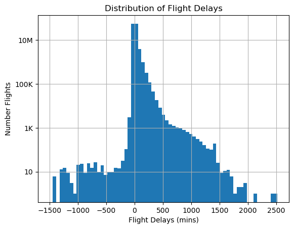

## Distribution of Airport Delays

Airport delays (dep_delay) just like the flight delays in the dataset take on a very large range of values, from about -1500 at the lowest, to about 2500 at the highest. Plotted on a logarithmic scale, the distribution of airport delay takes on a unimodal shape.

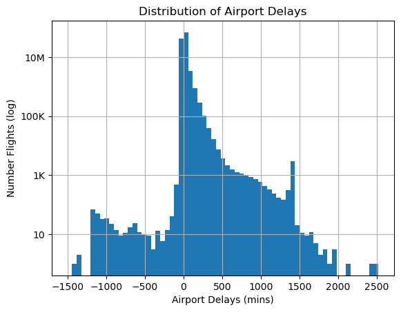

## Arrival delay vs. Departure delay

There appears to be strong positive relationship between arrival and departure delays.

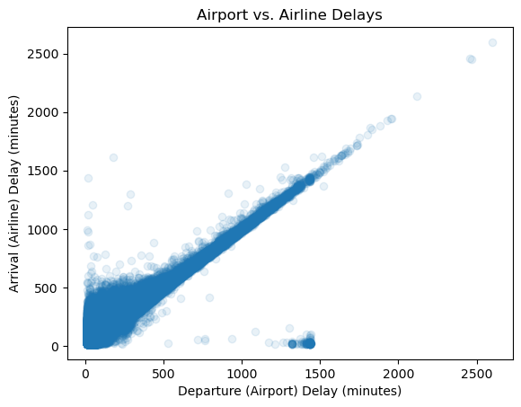

## Departure delay by Airports

The median flight delay at the Chicago O'Hare International airport (ORD) appears to be the highest across the top 5 airports.

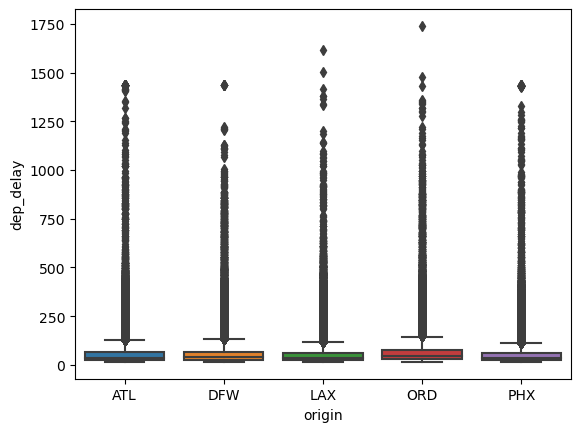

## Delayed Flights Trend by Airport by Year

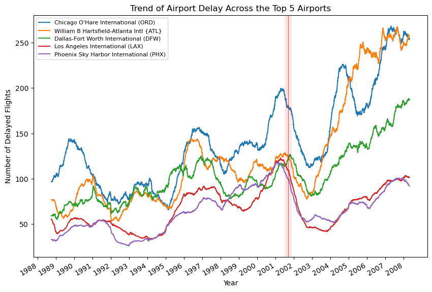

## Arrival vs Departure Delay by Airport

Across the major airports, there appears to be a strong relationship between arrival and depart delay.

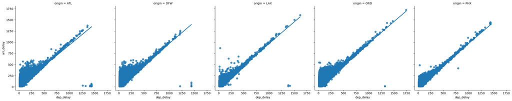